# Simulation of CLT

Alberto Macías

## Overview

In this project, we simulate the Central Limit Theorem (CLT) simulating one thousand samples of forty exponential random values and then compare the results of this simulation with the theoretical resuslts of the CLT.

## Simulations

We initiate simulating forty exponential random values and we make a histogram o look at the distribution of this sample:

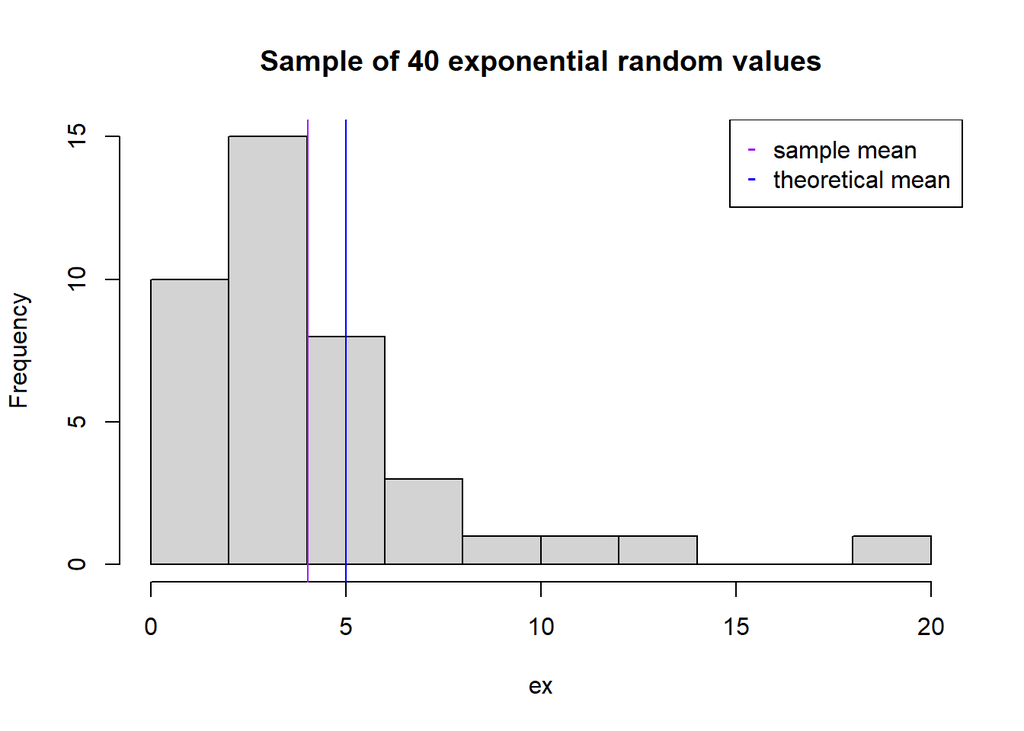

```r
set.seed(3487)
ex <- rexp(40, .2)
m <- round(mean(ex), digits = 3)
sde <- round(sd(ex), digits = 3)
v <- round(sde^2, digits = 3)
hist(ex, main = "Sample of 40 exponential random values")
abline(v=m, col="purple")
abline(v=1/0.2, col="blue")
legend("topright", pch = "-", col = c("purple", "blue"), legend = c("sample mean", "theoretical mean"))
```

From this plot we see that the distribution of the sample is far from been normal as we could expect. The theoretical mean is supposed to be 5 while the sample mean is approximately 4.016 and the theoretical standard deviation is also 5 and the sample standard deviation is 3.543. The theoretical variance of the an exponential random value is $5^2=25$ and the sample variance is around 12.553, showing that this sample is less variable that it is supposed to.

## Sample Mean and the CLT

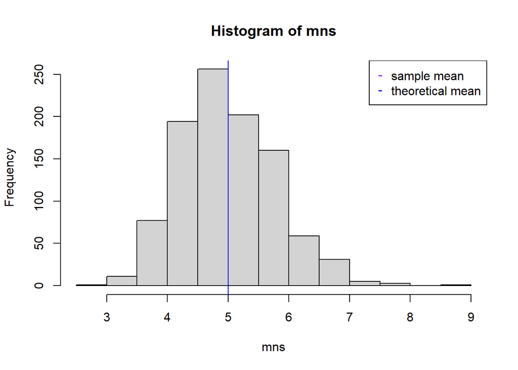

```r
mns <- NULL
for (i in 1 : 1000) mns = c(mns, mean(rexp(40, .2)))
hist(mns)
abline(v=mean(mns), col = "purple")
abline(v=5, col="blue")
legend("topright", pch = "-", col = c("purple", "blue"), legend = c("sample mean", "theoretical mean"))
```

## Conclusion

As the Central Limit Theorem states, if we take a large enough sample of random values of a distribution, in this case exponential, and we take the mean sample, this approximates to a normal distribution and it gets closer and closer if we take our sample larger and larger.